# Client Report - Project 4: Can you predict that?

- Show All Code
- Hide All Code

Course DS 250

Author

Leonardo Alvarino

## Elevator pitch

```python
# read the data
dwell= pd.read_csv("dwellings_ml.csv")

# delete yrbuilt and parcel
dwell= dwell.drop(['yrbuilt','parcel'], axis=1)
```

## QUESTION|TASK 1

The following code creates a scatter plot that helped me to analyze the effects,patterns the “total units” and “Number of bedrooms” variable have in relation to the “Before 1980” variable.

```python
fig = px.scatter(
    dwell,
    x='numbdrm',
    y='totunits',
    color='before1980'
)

fig.update_layout(
    xaxis_title="Number of bedrooms",
    yaxis_title="Total units",
    title="Scatter Plot of number of bedrooms vs total units"
)

fig.show()
```

[interactive chart not shown]

The next code creates 2 boxplots, one for houses before 1980 and the other of 1980 or after. This is very helpful to analyze the distribution of the variable “number of bathrooms” and the relationship with “before1980”.

```python
fig = px.box(
    dwell,
    x='before1980',
    y='numbaths',
    color= 'before1980',
)

fig.update_layout(
    xaxis_title="Before 1980",
    yaxis_title="Number of Bathrooms",
    title="Boxplot of Number of Bathrooms vs Before 1980"
)
fig.show()
```

[interactive chart not shown]

Findings:

- Apparently houses in the past (before 1980) used to have less bathrooms than now.
- Upper quartile of the houses built before 1980 is equal to the lower quartile to the houses built in 1980 or after.

## QUESTION|TASK 2

**Build a classification model labeling houses as being built “before 1980” or “during or after 1980”. Your goal is to reach or exceed 90% accuracy. Explain your final model choice (algorithm, tuning parameters, etc) and describe what other models you tried.**

The following code separates the data into 4 groups, Train X, Train y, TestX and TextY. This is the data preparation to fit the classifier “RandomForest” which I selected since it normally has a high accuracy with its predictions.

```python
X = dwell.drop(["before1980"], axis=1)
y = dwell["before1980"]

train_data, test_data, train_targets, test_targets = train_test_split(X, y, test_size=.30)

# RandomForestClassifier
classifier = RandomForestClassifier()
classifier.fit(train_data, train_targets)

targets_predicted = classifier.predict(test_data)
```

## QUESTION|TASK 3

**Justify your classification model by discussing the most important features selected by your model. This discussion should include a chart and a description of the features.**

The following code creates a chart of the classiffier features ranked by importance.

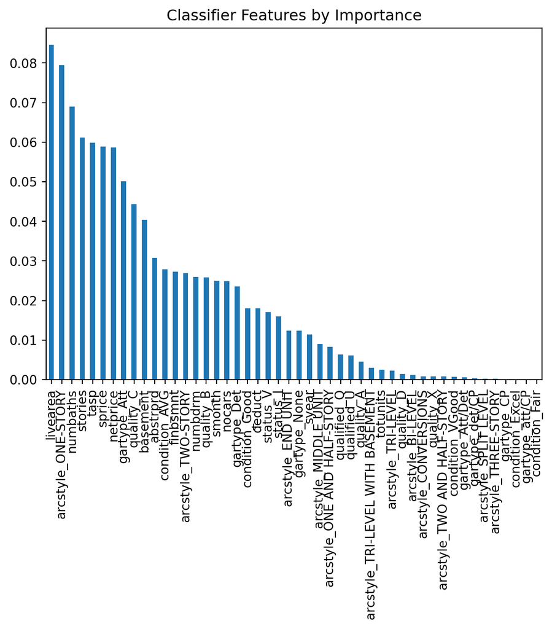

```python
# Create a series containing feature importances from the model and feature names from the training data
feature_importances = pd.Series(classifier.feature_importances_, index= train_data.columns).sort_values(ascending=False)

# Plot a simple bar chart
feature_importances.plot.bar(title = 'Classifier Features by Importance')
```

## QUESTION|TASK 4

**Describe the quality of your classification model using 2-3 different evaluation metrics. You also need to explain how to interpret each of the evaluation metrics you use.**

The next code chunk uses 2 Scikit-Learn methods to evaluate the classification model: Accuracy and confusion matrix.

```
Accuracy: 0.9217340704102415
```

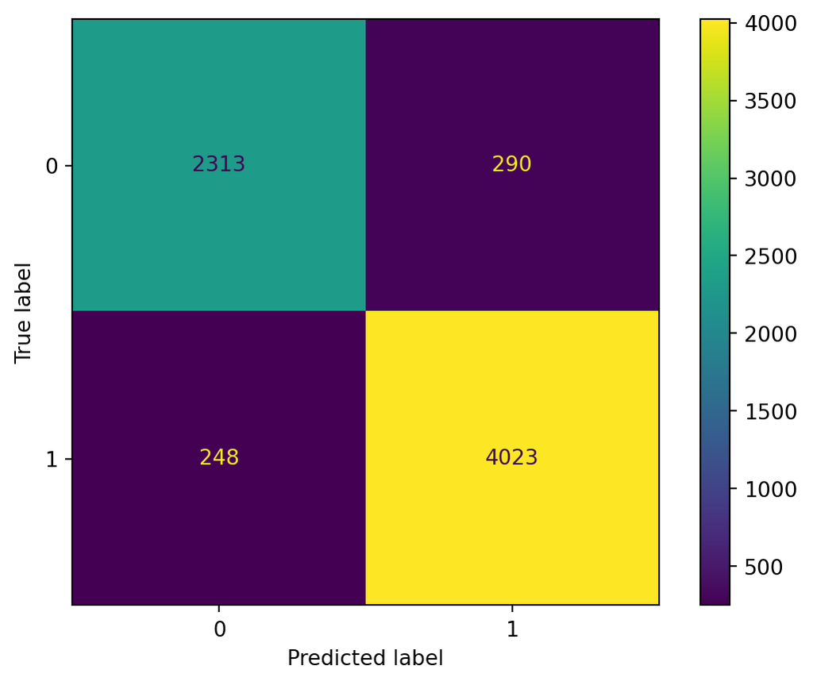

```python
print("Accuracy:", accuracy_score(test_targets, targets_predicted))

# Create the confusion matrix
cm = confusion_matrix(test_targets, targets_predicted)
ConfusionMatrixDisplay(confusion_matrix=cm).plot()
```